# Lab 1: Linear models for quantitative genetics

BMI 206

Wanjun Gu

Oct 19th, 2023

### PART1: Analyzing provided genotype and phenotype data.

**Load the packages needed.**

```r
suppressPackageStartupMessages({
  if(!require("data.table")){
    install.packages("data.table")
    library("data.table")
  }

  if(!require("dplyr")){
    install.packages("dplyr")
    library("dplyr")
  }

  if(!require("purrr")){
    install.packages("purrr")
    library("purrr")
  }

  if(!require("knitr")){
    install.packages("knitr")
    library("knitr")
  }

  if(!require("ggplot2")){
    install.packages("ggplot2")
    library("ggplot2")
  }

  if(!require("gridExtra")){
    install.packages("gridExtra")
    library("gridExtra")
  }
})
```

**Prepare the data.** Read in the genotype and phenotype matrices.

```r
genos = as.matrix(read.table("./genos.txt"))
phenos = as.matrix(read.table("./phenos.txt"))
```

Make a histogram of the phenotypes. Do they look normally distributed?

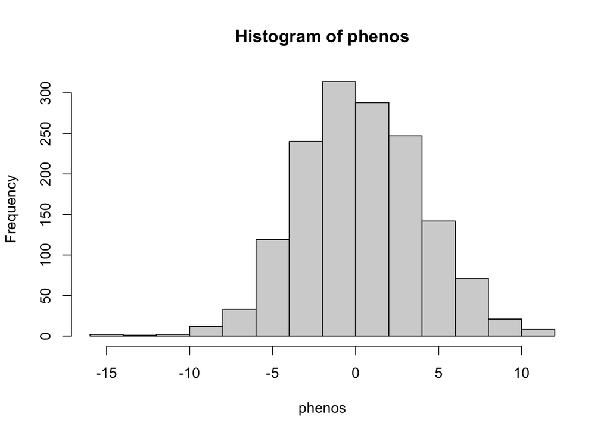

```r
hist(phenos)
```

How are the genotypes encoded?

```r
table(genos)
```

```
## genos
##       0       1       2
## 4773842 5447131 4779027
```

How many individuals are there in the dataset and how many SNPs? (Save them in `N` and `M`, respectively.)

```r
dim(genos)
```

```
## [1]  1500 10000
```

```r
dim(phenos)
```

```
## [1] 1500    1
```

```r
N = 1500
M = 10000
```

**Compute the *minor* allele frequency for every SNP. Check MAFs are <0.5.**

```r
# MAFs = array(0,M)
# for(i in 1:M) {
#       MAFs[i] = ?
# }
MAFs = apply(genos, MARGIN = 2, function(x){
  af = sum(x)/(2*length(x))
  maf = ifelse(af >= 0.5, 1-af, af)
  return(maf)
})
names(MAFs) = NULL
MAFs[1:10]
```

```
##  [1] 0.1516667 0.3226667 0.4126667 0.2156667 0.4626667 0.4826667 0.4863333
##  [8] 0.1516667 0.2990000 0.3310000
```

```r
max(MAFs)
```

```
## [1] 0.5
```

**Run a GWAS under an additive model and save the p-values, z-scores, and effect sizes.**

```r
# pvalues = array(0,M)
# zscores = array(0,M)
# betas = array(0,M)
# for(i in 1:M) {
#   g = genos[,i]
#   res = summary(lm(?))
#   zscores[i] = ?
#     pvalues[i] = ?
#     betas[i] = ?
# }

res = apply(genos, MARGIN = 2,
            function(x){
              d = data.frame(
                phenotype = as.vector(phenos),
                genotype = x
              )

              l = summary(lm(data = d, formula = phenotype ~ genotype))
              res = data.frame(
                zscore = l$coefficients[2,3],
                pvalue = l$coefficients[2,4],
                beta = l$coefficients[2,1]
              )

              return(res)
            }, simplify = TRUE) %>%
  reduce(rbind.data.frame)
```

Summarize the effect sizes.

```r
summary(res$beta)
```

```
##      Min.   1st Qu.    Median      Mean   3rd Qu.      Max.
## -3.400728 -0.105822  0.002475  0.004204  0.113524  2.245525
```

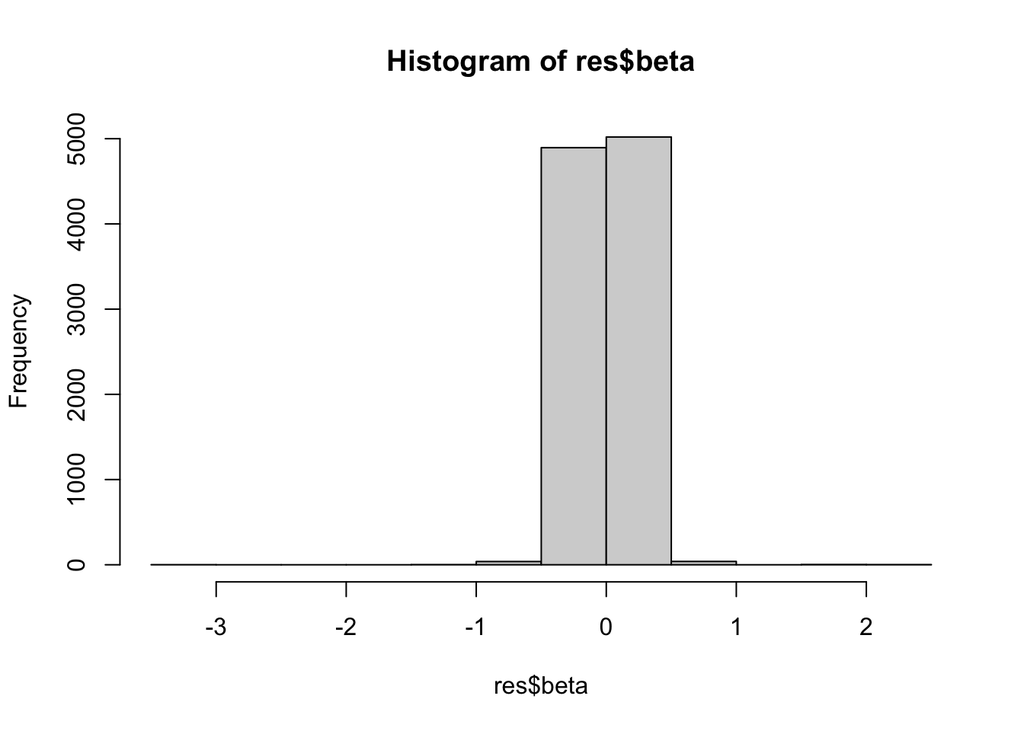

```r
hist(res$beta)
```

Are there any significantly associated SNPs? If so, which SNPs are they?

```r
p_adj = p.adjust(res$pvalue, method = "fdr")
assoc = which(p_adj<0.05)
assoc
```

```
##  [1]  1  2  3  4  5  6  7  8  9 10
```

How big are their effect sizes? How significant are they?

```r
# res$beta[assoc]
# res$zscore[assoc]
# res$pvalue[assoc]
kable(res[assoc,])
```

| zscore | pvalue | beta |
| --- | --- | --- |
| -21.021900 | 0e+00 | -3.4007282 |
| 16.013141 | 0e+00 | 2.1340404 |
| 11.615036 | 0e+00 | 1.5238919 |
| 5.003065 | 6e-07 | 0.7930685 |
| -11.436804 | 0e+00 | -1.4787008 |
| 16.128209 | 0e+00 | 1.9852459 |
| -9.115941 | 0e+00 | -1.2225227 |
| 12.602187 | 0e+00 | 2.2455246 |
| 13.341784 | 0e+00 | 1.8605128 |
| 5.383964 | 1e-07 | 0.7607997 |

Draw a QQ plot for log10(p) values.

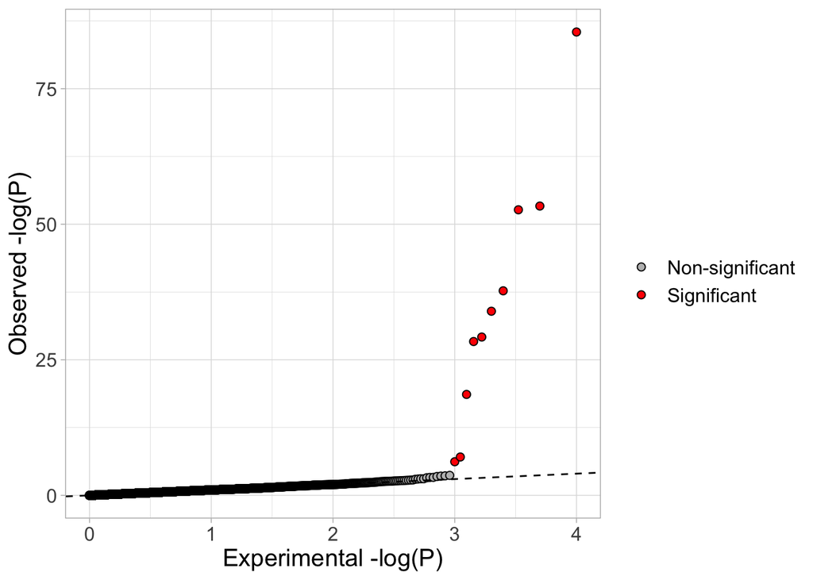

```r
obsLogPvs = sort(-log10(res$pvalue))
expLogPvs = sort(-log10(seq(1/M,1,1/M)))

qqplot_d = data_frame(
  obsLogPvs,
  expLogPvs,
) %>%
  mutate(fdr = 10^(-obsLogPvs)) %>%
  mutate(fdr = p.adjust(fdr)) %>%
  mutate(sig = ifelse(fdr <= 0.05, "Significant", "Non-significant"))
# plot(expLogPvs,obsLogPvs,main='QQ plot')

ggplot(data = qqplot_d, aes(x = expLogPvs, y = obsLogPvs)) +
  geom_point(aes(fill = sig), size = 2, color = "black", shape = 21) +
  scale_fill_manual(values = c("gray", "red")) +
  geom_abline(slope = 1, intercept = 0, linetype = "dashed") +
  labs(fill = "") +
  xlab("Experimental -log(P)") +
  ylab("Observed -log(P)") +
  theme_light() +
  theme(text = element_text(size = 15))
```

```r
# abline( a=0, b=1 )
#label the significant SNPs red
# points(expLogPvs[(M-length(assoc)):M],obsLogPvs[(M-length(assoc)):M],col="red")
```

Is there inflation? Use the chi-square statistics to check.

The median of Chi square distribution with one degree of freedom is 0.454

```r
chis = res$zscore^2
lambdaGC = median(chis)/0.454 # why .454?
lambdaGC
```

```
## [1] 1.007873
```

Plot the phenotype predictions for the most significant SNP.

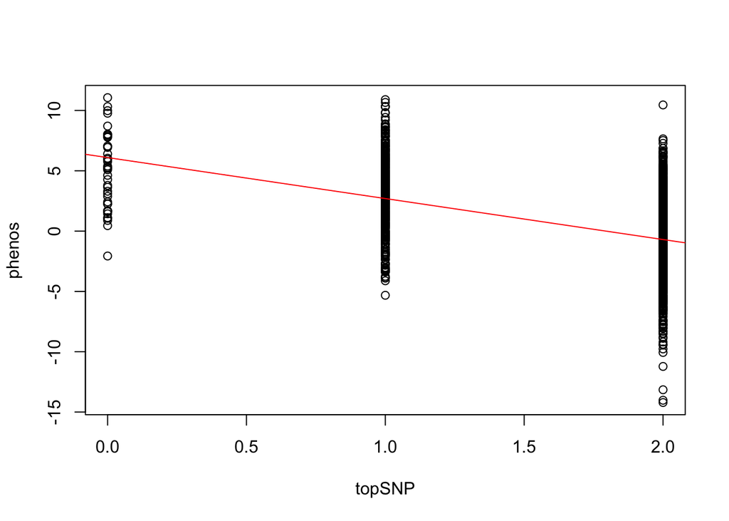

```r
topSNP = genos[,order(res$pvalue)[1]]
plot(topSNP,phenos)
abline(lm(phenos~topSNP)$coeff,col="red")
```

**Build a linear predictor of the phenotype using the associated SNPs.**

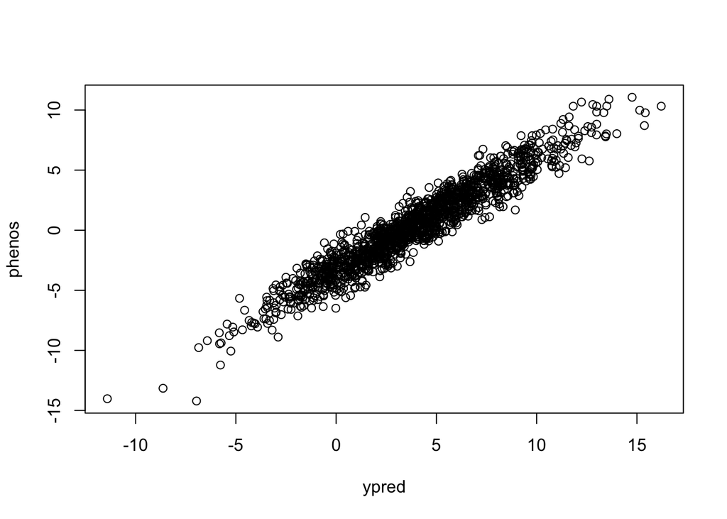

```r
ypred = array(0,N)
for(i in 1:N) {
  ypred[i] = genos[i,assoc] %*% res$beta[assoc]
}
plot(ypred,phenos)
```

What is the correlation between the predicted phenotype and the true phenotype?

```r
cor(ypred,phenos)
```

```
##             V1
## [1,] 0.9582865
```

**BONUS: Test each of the associated SNPs for non-linearity.**

The p-value from the ANOVA test is significant for the first SNP (unadjusted). This indicate that the first variant may be non-linearily associated with the phenotype.

```r
hp = array(0,length(assoc))
for (i in 1:length(assoc)) {
  g = genos[,assoc[i]]
  h = g
  h[h==2]=0
  #Hint: can use anova(lm(?),lm(?)) or summary(lm(?))
  linear_model = lm(phenos~g)
  non_linear_model = lm(phenos~g+h)

  hp[i] = anova(linear_model, non_linear_model)$Pr[2] #skip multiple test correction for now
}
hp
```

```
##  [1] 0.0008859446 0.9243902273 0.4974970958 0.1514667494 0.4854254373
##  [6] 0.1959153850 0.1201895538 0.1931039794 0.8697644428 0.4132013052
```

**BONUS: Visualize a linear SNP and a non-linear SNP.**

In this figure, the coral line of the boxplot is the mean of each group.

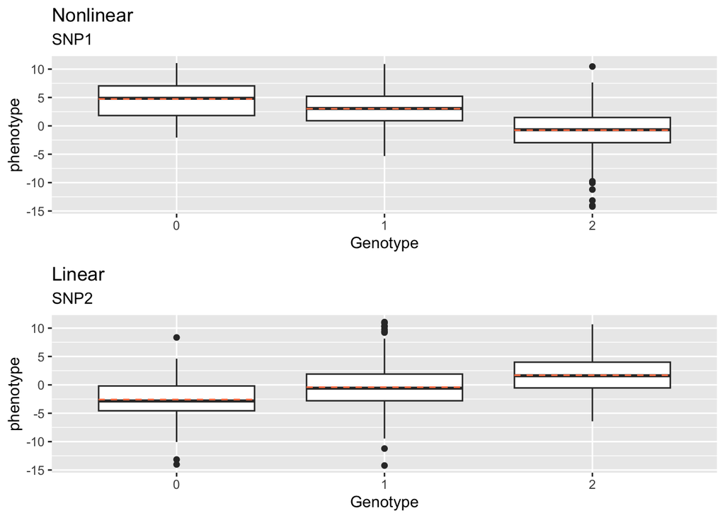

```r
non_linear_data = data.frame(
  genotype = genos[, assoc[which.min(hp)]],
  phenotype = as.vector(phenos)
)

plt1 = ggplot(data = non_linear_data, aes(x = as.factor(genotype), y = phenotype)) +
  geom_boxplot() +
  stat_summary(fun = mean, geom = "errorbar", aes(ymax = ..y.., ymin = ..y..),
               width = .75, linetype = "dashed", color = "coral") +
  xlab("Genotype") +
  ggtitle(label = "Nonlinear", subtitle = "SNP1")

linear_data = data.frame(
  genotype = genos[, assoc[which.max(hp)]],
  phenotype = as.vector(phenos)
)

plt2 = ggplot(data = linear_data, aes(x = as.factor(genotype), y = phenotype)) +
  geom_boxplot() +
  stat_summary(fun = mean, geom = "errorbar", aes(ymax = ..y.., ymin = ..y..),
               width = .75, linetype = "dashed", color = "coral") +
  xlab("Genotype") +
  ggtitle(label = "Linear", subtitle = "SNP2")

grid.arrange(plt1, plt2)
```

```r
# par(mfrow=c(1,2))
#
# plot(g = genos[, assoc[]], phenos)
# points( c(0,1,2), tapply( ?, ?, mean ), col=2, pch=16, cex=3 )
# lines( c(0,1,2), tapply( ?, ?, mean ), col=2, lwd=2  )
# plot( ?, ? )
# points( c(0,1,2), tapply( ?, ?, mean ), col=2, pch=16, cex=3 )
# lines( c(0,1,2), tapply( ?, ?, mean ), col=2, lwd=2  )
```

**Repeat the GWAS to test for recessive rather than additive genetic effects.**

```r
genos2 = genos
genos2[genos<1]=1

res2 = apply(genos2, MARGIN = 2,
             function(x){
               d = data.frame(
                 phenotype = as.vector(phenos),
                 genotype = x
               )

               l = summary(lm(data = d, formula = phenotype ~ genotype))
               res = data.frame(
                 zscore = l$coefficients[2,3],
                 pvalue = l$coefficients[2,4],
                 beta = l$coefficients[2,1]
               )

               return(res)
             }, simplify = TRUE) %>%
  reduce(rbind.data.frame)

# pvalues2 = array(0,M)
# zscores2 = array(0,M)
# betas2 = array(0,M)
# for(i in 1:M) {
#   g = genos2[,i]
#   res = summary(lm(?))
#   zscores2[i] = ?
#     pvalues2[i] = ?
#     betas2[i] = ?
# }
```

**Are the same SNPs significant or not?**

```r
p_adj2 = p.adjust(res2$pvalue, n = dim(res2)[1], method = "fdr")

assoc2 = which(p_adj2<0.05)
assoc2
```

```
##  [1]  1  2  3  4  5  6  7  8  9 10
```

**How did the effect sizes change?**  
The effect size becomes larger

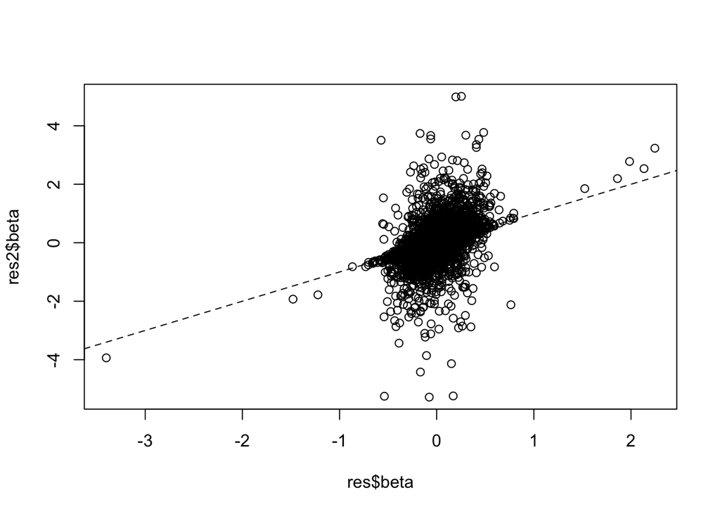

```r
plot(res$beta,res2$beta)
abline(a = 0, b = 1, lty = "dashed")
```

```r
summary(lm(d = data.frame(beta1 = res$beta, beta2 = res2$beta),
           formula = beta2 ~ beta1))
```

```
##
## Call:
## lm(formula = beta2 ~ beta1, data = data.frame(beta1 = res$beta,
##     beta2 = res2$beta))
##
## Residuals:
##     Min      1Q  Median      3Q     Max
## -5.4772 -0.1011 -0.0039  0.0956  4.7141
##
## Coefficients:
##             Estimate Std. Error t value Pr(>|t|)
## (Intercept) 0.005182   0.004083   1.269    0.204
## beta1       1.361376   0.022519  60.454   <2e-16 ***
## ---
## Signif. codes:  0 '***' 0.001 '**' 0.01 '*' 0.05 '.' 0.1 ' ' 1
##
## Residual standard error: 0.4082 on 9998 degrees of freedom
## Multiple R-squared:  0.2677, Adjusted R-squared:  0.2676
## F-statistic:  3655 on 1 and 9998 DF,  p-value: < 2.2e-16
```

### PART2: Simulating genotypes with LD.

**Establish some important simulation parameters.**

```r
N = 1000 #number of individuals
M = 30   #number of non-causal SNPs
gs = matrix(0,nrow=N,ncol=M)
```

**Simulate a GWAS data set.** First, simulate the causal variant.

```r
set.seed = (42) #set random seed so we all get the same numbers
MAF = 0.5
gC = rbinom(N,1,MAF) #causal variant
```

Then, simulate the phenotypes given the causal variant.

```r
beta = 0.3 #association of causal variant
pheno = gC*beta + rnorm(N)
```

Generate 10 SNPS in tight LD with the causal SNP.

```r
rho = 0.9
for(i in 1:10) {
  idx = rbinom(N,1,rho)
  gs[,i]=gC*idx+rbinom(N,1,MAF)*(1-idx)
  # test they have the right LD empirically
  cat( 'Observed LD = ', cor( gs[,i], gC ), '\n' )
  # Bonus: prove they have the right LD theoretically
}
```

```
## Observed LD =  0.9081689
## Observed LD =  0.8857501
## Observed LD =  0.885919
## Observed LD =  0.911837
## Observed LD =  0.8898133
## Observed LD =  0.8841377
## Observed LD =  0.8979379
## Observed LD =  0.8900175
## Observed LD =  0.90379
## Observed LD =  0.9259237
```

Do the same for 10 moderate LD partners (rho=0.6).

```r
rho = 0.6
for(i in 11:20) {
  idx = rbinom(N,1,rho)
  gs[,i]=gC*idx+rbinom(N,1,MAF)*(1-idx)
  # test they have the right LD empirically
  cat( 'Observed LD = ', cor( gs[,i], gC ), '\n' )
  # Bonus: prove they have the right LD theoretically
}
```

```
## Observed LD =  0.539599
## Observed LD =  0.6134913
## Observed LD =  0.6177276
## Observed LD =  0.6172265
## Observed LD =  0.6330225
## Observed LD =  0.5859592
## Observed LD =  0.6471937
## Observed LD =  0.5864415
## Observed LD =  0.6336309
## Observed LD =  0.6050128
```

Do the same for 10 independent SNPs (rho=0).

```r
rho = 0
for(i in 21:30) {
  idx = rbinom(N,1,rho)
  gs[,i]=gC*idx+rbinom(N,1,MAF)*(1-idx)
  # test they have the right LD empirically
  cat( 'Observed LD = ', cor( gs[,i], gC ), '\n' )
  # Bonus: prove they have the right LD theoretically
}
```

```
## Observed LD =  0.08283428
## Observed LD =  0.01355009
## Observed LD =  0.0345911
## Observed LD =  -0.02448714
## Observed LD =  -0.006559415
## Observed LD =  -0.01759278
## Observed LD =  0.06128156
## Observed LD =  0.02578987
## Observed LD =  0.04580572
## Observed LD =  0.01145408
```

**Run GWAS on the causal variant. Then run GWAS on the other variants. Keep track of the zscores only.**

```r
zsC = summary(lm(pheno~gC))$coef[2,3]
zs = sapply(1:M, function(i){
  try({
    return(
      summary(lm(pheno~gs[,i]))$coef[2,3]
    )
  }, silent = TRUE)
  return(0)
})
```

Visualize the relationship between the mean z-scores at the tag SNPs and the z-score at the causal SNP.

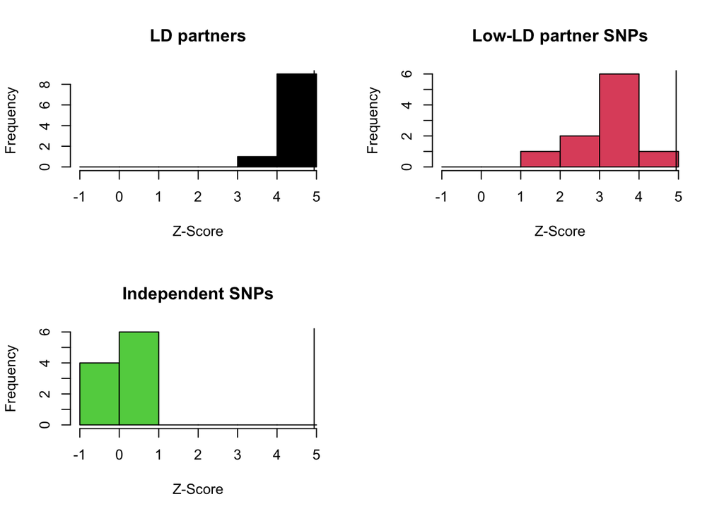

```r
par(mfrow=c(2,2) )
breaks = hist(c(0,zsC,zs),plot=F)$breaks
hist(zs[1:10],breaks=breaks, col=1, main='LD partners', xlab = "Z-Score")
abline(v=zsC)
hist(zs[11:20],breaks=breaks, col=2, main='Low-LD partner SNPs', xlab = "Z-Score")
abline(v=zsC)
hist(zs[21:30],breaks=breaks, col=3, main='Independent SNPs', xlab = "Z-Score")
abline(v=zsC)
```

**BONUS: Perform LD score regression. First, calculate the LD scores. There should be M+1 of them.**

```r
ldscores = cor(cbind(gC, gs))^2
colnames(ldscores) = paste0("SNP", 0:30)
rownames(ldscores) = paste0("SNP", 0:30)
ldscores = apply(ldscores, 1, sum)
```

**BONUS: Visualize LD score regression.**

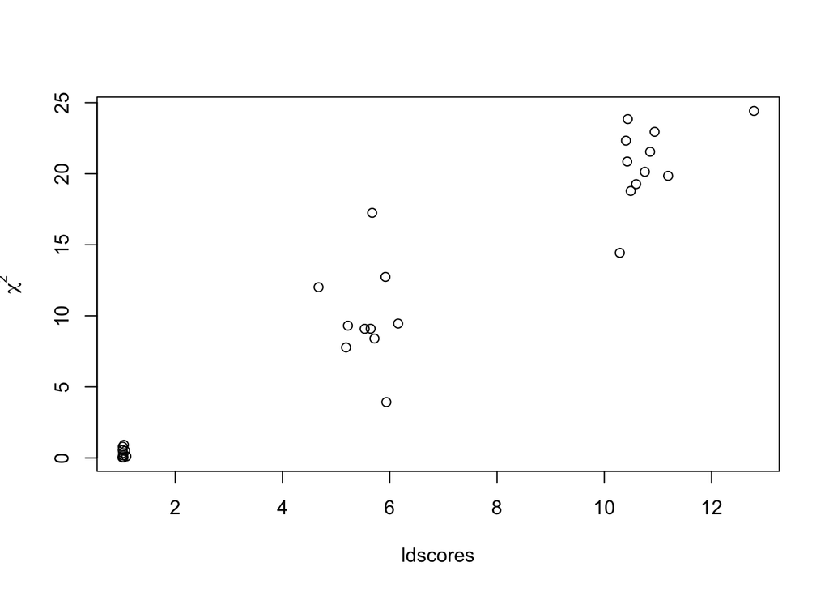

```r
chis = c(zsC,zs)^2
plot(ldscores, chis, ylab=expression(chi^2) )
```

```r
#test for inflation
lambdaGC = median(chis)/0.454
lambdaGC
```

```
## [1] 20.50415
```

**BONUS: Estimate heritability.**

```r
summary(lm(chis~ldscores))$coef[2,1] * M/N
```

```
## [1] 0.06212776
```

**BONUS: What is the true heritability?**

```r
var(gC*beta) / var(pheno)
```

```
## [1] 0.02065499
```